# HerbPt1 16S Figures

```r
require(phyloseq)
require(tidyverse)
require(reshape2)
require(dplyr)
require(ggplot2)
require(vegan)
```

Load data order, factors, and create a mode (chemical, hand, non-treated) column.

```r
ps_dmn <- readRDS("/Users/gordoncuster/Desktop/Git_Projects/Herbicide_Microbes_PT1/data/PhyloseqObjects/16S/DMN_ests_16S.Rdata")
sample_data(ps_dmn)$Herbicide <- factor(sample_data(ps_dmn)$Herbicide, levels = c("Aatrex", "Clarity", "Hand","Non-Treated","Roundup Powermax"))
sample_data(ps_dmn)$herb_time<-paste(sample_data(ps_dmn)$Herbicide, sample_data(ps_dmn)$Time, sep = "_")

#regroup all chemical treatments together and rerun betadiv calcs within group.
sample_data(ps_dmn)$Mode<-sample_data(ps_dmn)$Herbicide

index <- c("Clarity", "Roundup Powermax", "Aatrex", "Hand", "Non-Treated")
values <- c("Chemical", "Chemical", "Chemical", "Hand", "Non-Treated")

sample_data(ps_dmn)$Mode<- as.factor(values[match(sample_data(ps_dmn)$Mode, index)])


index <- c("Clarity", "Roundup Powermax", "Aatrex", "Hand", "Non-Treated")
values <- c("Dicamba", "Glyphosate", "Atrazine-Mesotrione", "Handweeded", "Non-Treated")

sample_data(ps_dmn)$Herbicide <- as.factor(values[match(sample_data(ps_dmn)$Herbicide, index)])



ps_rare <- readRDS("/Users/gordoncuster/Desktop/Git_Projects/Herbicide_Microbes_PT1/data/PhyloseqObjects/16S/HerbPt1_rare_16S.Rdata")
sample_data(ps_rare)$Herbicide <- factor(sample_data(ps_rare)$Herbicide, levels = c("Aatrex", "Clarity", "Hand","Non-Treated","Roundup Powermax"))
sample_data(ps_rare)$herb_time<-paste(sample_data(ps_rare)$Herbicide, sample_data(ps_rare)$Time, sep = "_")


#regroup all chemical treatments together and rerun betadiv calcs within group.
sample_data(ps_rare)$Mode<-sample_data(ps_rare)$Herbicide

index <- c("Clarity", "Roundup Powermax", "Aatrex", "Hand", "Non-Treated")
values <- c("Chemical", "Chemical", "Chemical", "Hand", "Non-Treated")

sample_data(ps_rare)$Mode<- as.factor(values[match(sample_data(ps_rare)$Mode, index)])

index <- c("Clarity", "Roundup Powermax", "Aatrex", "Hand", "Non-Treated")
values <- c("Dicamba", "Glyphosate", "Atrazine-Mesotrione", "Handweeded", "Non-Treated")

sample_data(ps_rare)$Herbicide <- as.factor(values[match(sample_data(ps_rare)$Herbicide, index)])

ps_trans <- readRDS("/Users/gordoncuster/Desktop/Git_Projects/Herbicide_Microbes_PT1/data/PhyloseqObjects/16S/HerbPt1_hel_trans_16S.Rdata")
sample_data(ps_trans)$Herbicide <- factor(sample_data(ps_trans)$Herbicide, levels = c("Aatrex", "Clarity", "Hand","Non-Treated","Roundup Powermax"))
sample_data(ps_trans)$herb_time<-paste(sample_data(ps_trans)$Herbicide, sample_data(ps_trans)$Time, sep = "_")

#regroup all chemical treatments together and rerun betadiv calcs within group.
sample_data(ps_trans)$Mode<-sample_data(ps_trans)$Herbicide

index <- c("Clarity", "Roundup Powermax", "Aatrex", "Hand", "Non-Treated")
values <- c("Chemical", "Chemical", "Chemical", "Hand", "Non-Treated")

sample_data(ps_trans)$Mode<- as.factor(values[match(sample_data(ps_trans)$Mode, index)])

index <- c("Clarity", "Roundup Powermax", "Aatrex", "Hand", "Non-Treated")
values <- c("Dicamba", "Glyphosate", "Atrazine-Mesotrione", "Handweeded", "Non-Treated")

sample_data(ps_trans)$Herbicide <- as.factor(values[match(sample_data(ps_trans)$Herbicide, index)])
```

create alpha diversity tables

```r
alpha_div <- estimate_richness(physeq = ps_rare, measures = c("Observed", "Shannon", "Chao1"))
#pull out metadata and concatonate with alpha diversity metrics
md<-data.frame(sample_data(ps_rare))
alpha_div_md <- rownames_to_column(alpha_div, "Barcode_ID_G") %>% full_join(md)
alpha_div_md$Herbicide <- factor(alpha_div_md$Herbicide, levels = c("Non-Treated", "Handweeded", "Atrazine-Mesotrione", "Dicamba", "Glyphosate"))
```

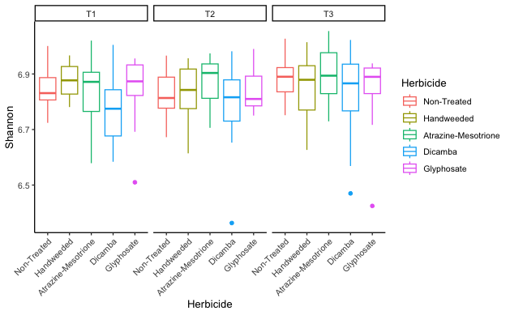

```r
ggplot(data = alpha_div_md, aes(Herbicide, Shannon, color= Herbicide)) + facet_grid(. ~ Time) + geom_boxplot() + theme_classic() + theme(axis.text.x = element_text(angle = 45, hjust = 1) )

ggsave("/Users/gordoncuster/Desktop/Git_Projects/Herbicide_Microbes_PT1/Figures/16S_Shannon.pdf")
```

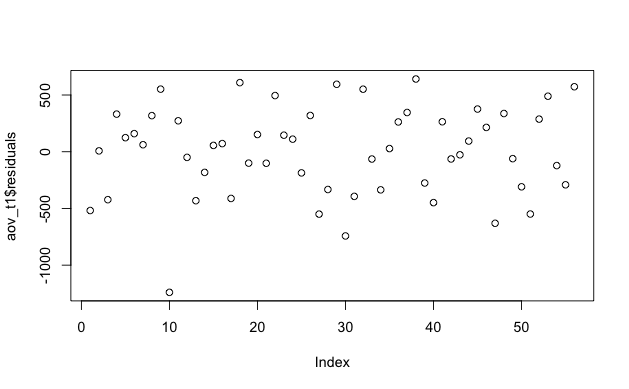

```r
aov_t1<-aov(Chao1 ~ Herbicide, data = alpha_div_md[alpha_div_md$Time == "T1",])
plot(aov_t1$residuals)
```

```r
summary(aov_t1)
```

```
            Df  Sum Sq Mean Sq F value Pr(>F)
Herbicide    4   66537   16634   0.099  0.982
Residuals   51 8553352  167713
```

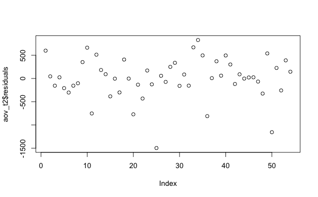

```r
aov_t2<-aov(Chao1 ~ Herbicide, data = alpha_div_md[alpha_div_md$Time == "T2",])
plot(aov_t2$residuals)
```

```r
summary(aov_t2)
```

```
            Df   Sum Sq Mean Sq F value Pr(>F)
Herbicide    4   652901  163225   0.779  0.545
Residuals   49 10272922  209651
```

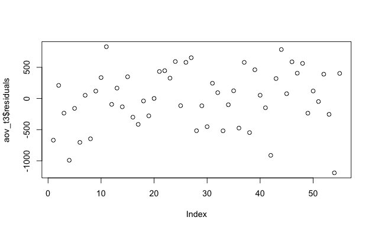

```r
aov_t3<-aov(Chao1 ~ Herbicide, data = alpha_div_md[alpha_div_md$Time == "T3",])
plot(aov_t3$residuals)
```

```r
summary(aov_t3)
```

```
            Df   Sum Sq Mean Sq F value Pr(>F)
Herbicide    4   433435  108359   0.465  0.761
Residuals   50 11641251  232825
```

remove outliers and rare reads with less than 2 total reads

```r
ps_dmn <-  subset_samples(ps_dmn, sample_names(ps_rare) != "G166SG")

ps_rare <-  subset_samples(ps_rare, sample_names(ps_rare) != "G166SG")
ps_rare_sub<-prune_taxa(taxa_sums(ps_rare) > 2, ps_rare)

ps_trans_sub<-prune_taxa(taxa_sums(ps_trans) > 0.05, ps_trans)
```

```r
ord_dmn<-ordinate(physeq = ps_dmn, method = "NMDS", distance = "bray", k=3, trymax= 300, maxit=1000)
```

```
*** Best solution repeated 1 times
```

```r
ord_rare<-ordinate(physeq = ps_rare_sub, method = "NMDS", distance = "bray", k=3, trymax= 300, maxit=1000)
```

```
Square root transformation
Wisconsin double standardization
*** Best solution repeated 1 times
```

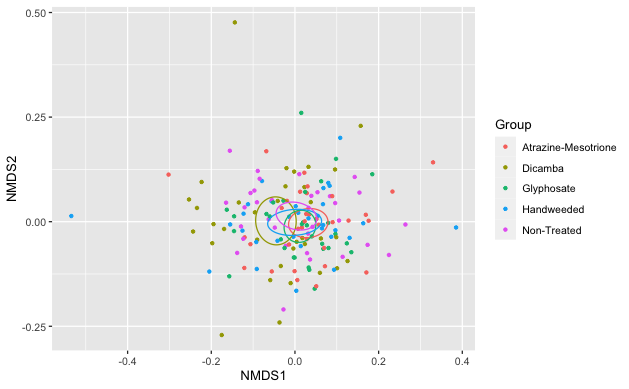

```r
full_ord_rare<-ggordiplots::gg_ordiplot(ord = ord_rare, groups = data.frame(sample_data(ps_rare))$Herbicide, choices = c(1, 2), kind = c("se"), conf = 0.95, show.groups = "all", ellipse = TRUE, label = FALSE, hull = FALSE, spiders = FALSE, plot = TRUE, pt.size = 1)
```

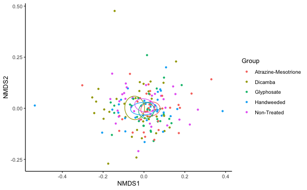

```r
full_ord_rare$plot + theme_classic()
```

```r
ord_transformed<-ordinate(physeq = ps_trans_sub, method = "NMDS", distance = "bray", trymax= 300, maxit=1000)
```

```
*** Best solution repeated 1 times
```

Adonis testing of herbicide treatments by time point

```r
ps_adonis<-function(physeq){
  otu_tab<-data.frame(phyloseq::otu_table(physeq))
  md_tab<-data.frame(phyloseq::sample_data(physeq))
    if(taxa_are_rows(physeq)== T){
       physeq_dist<-parallelDist::parDist(as.matrix(t(otu_tab)), method = "bray")}
            else{physeq_dist<-parallelDist::parDist(as.matrix(otu_tab), method = "bray")}
  print(anova(vegan::betadisper(physeq_dist, md_tab$Herbicide)))
  vegan::adonis2(physeq_dist ~ Herbicide * Time + Total_Weed_Veg , data = md_tab, permutations = 1000)
}
```

remove one sample with no vegetation measurement.

```r
ps_rare_sub_57<-subset_samples(ps_rare_sub, sample_names(ps_rare_sub) != "G065SG")
ps_adonis(ps_rare_sub_57)
```

```
Analysis of Variance Table

Response: Distances
           Df   Sum Sq    Mean Sq F value Pr(>F)
Groups      4 0.002272 0.00056790  0.7161 0.5821
Residuals 158 0.125304 0.00079307
Permutation test for adonis under reduced model
Terms added sequentially (first to last)
Permutation: free
Number of permutations: 1000

vegan::adonis2(formula = physeq_dist ~ Herbicide * Time + Total_Weed_Veg, data = md_tab, permutations = 1000)
                Df SumOfSqs      R2      F   Pr(>F)
Herbicide        4   0.7426 0.02683 1.1009 0.039960 *
Time             2   0.3691 0.01334 1.0942 0.113886
Total_Weed_Veg   1   0.1683 0.00608 0.9982 0.430569
Herbicide:Time   8   1.6044 0.05797 1.1892 0.000999 ***
Residual       147  24.7901 0.89577
Total          162  27.6746 1.00000
---
Signif. codes:  0 ‘***’ 0.001 ‘**’ 0.01 ‘*’ 0.05 ‘.’ 0.1 ‘ ’ 1
```

```r
ps_dmn_57<-subset_samples(ps_dmn, sample_names(ps_dmn) != "G065SG")
ps_adonis(ps_dmn_57)
```

```
Analysis of Variance Table

Response: Distances
           Df   Sum Sq   Mean Sq F value  Pr(>F)
Groups      4 0.018557 0.0046394  2.7215 0.03142 *
Residuals 163 0.277872 0.0017047
---
Signif. codes:  0 ‘***’ 0.001 ‘**’ 0.01 ‘*’ 0.05 ‘.’ 0.1 ‘ ’ 1
Permutation test for adonis under reduced model
Terms added sequentially (first to last)
Permutation: free
Number of permutations: 1000

vegan::adonis2(formula = physeq_dist ~ Herbicide * Time + Total_Weed_Veg, data = md_tab, permutations = 1000)
                Df SumOfSqs      R2      F   Pr(>F)
Herbicide        4   0.2207 0.04858 2.2897 0.000999 ***
Time             2   0.1021 0.02247 2.1183 0.002997 **
Total_Weed_Veg   1   0.0308 0.00678 1.2791 0.169830
Herbicide:Time   8   0.5269 0.11600 2.7338 0.000999 ***
Residual       152   3.6623 0.80618
Total          167   4.5428 1.00000
---
Signif. codes:  0 ‘***’ 0.001 ‘**’ 0.01 ‘*’ 0.05 ‘.’ 0.1 ‘ ’ 1
```

effect of herbicide treatment at each timepoint as per significant interaction term.

```r
ps_adonis_split_by_timepoint<-function(physeq){
  otu_tab<-data.frame(phyloseq::otu_table(physeq))
  md_tab<-data.frame(phyloseq::sample_data(physeq))
    if(taxa_are_rows(physeq)== T){
       physeq_dist<-parallelDist::parDist(as.matrix(t(otu_tab)), method = "bray")}
            else{physeq_dist<-parallelDist::parDist(as.matrix(otu_tab), method = "bray")}
  print(anova(vegan::betadisper(physeq_dist, md_tab$Herbicide)))
  vegan::adonis2(physeq_dist ~ Herbicide + Total_Weed_Veg , data = md_tab, permutations = 1000)
}


#rarefied
ps_rare_sub_57_T1<-subset_samples(ps_rare_sub_57, Time=="T1")
ps_adonis_split_by_timepoint(ps_rare_sub_57_T1)
```

```
Analysis of Variance Table

Response: Distances
          Df   Sum Sq    Mean Sq F value Pr(>F)
Groups     4 0.002840 0.00070997   1.074 0.3791
Residuals 51 0.033714 0.00066106
Permutation test for adonis under reduced model
Terms added sequentially (first to last)
Permutation: free
Number of permutations: 1000

vegan::adonis2(formula = physeq_dist ~ Herbicide + Total_Weed_Veg, data = md_tab, permutations = 1000)
               Df SumOfSqs      R2      F  Pr(>F)
Herbicide       4   0.7959 0.08320 1.1592 0.01499 *
Total_Weed_Veg  1   0.1886 0.01971 1.0987 0.16384
Residual       50   8.5825 0.89709
Total          55   9.5670 1.00000
---
Signif. codes:  0 ‘***’ 0.001 ‘**’ 0.01 ‘*’ 0.05 ‘.’ 0.1 ‘ ’ 1
```

```r
ps_rare_sub_57_T2<-subset_samples(ps_rare_sub_57, Time=="T2")
ps_adonis_split_by_timepoint(ps_rare_sub_57_T2)
```

```
Analysis of Variance Table

Response: Distances
          Df   Sum Sq    Mean Sq F value Pr(>F)
Groups     4 0.002159 0.00053984  0.6887 0.6034
Residuals 48 0.037627 0.00078390
Permutation test for adonis under reduced model
Terms added sequentially (first to last)
Permutation: free
Number of permutations: 1000

vegan::adonis2(formula = physeq_dist ~ Herbicide + Total_Weed_Veg, data = md_tab, permutations = 1000)
               Df SumOfSqs      R2      F  Pr(>F)
Herbicide       4   0.7058 0.08094 1.0622 0.09990 .
Total_Weed_Veg  1   0.2065 0.02368 1.2430 0.03596 *
Residual       47   7.8076 0.89538
Total          52   8.7199 1.00000
---
Signif. codes:  0 ‘***’ 0.001 ‘**’ 0.01 ‘*’ 0.05 ‘.’ 0.1 ‘ ’ 1
```

```r
ps_rare_sub_57_T3<-subset_samples(ps_rare_sub_57, Time=="T3")
ps_adonis_split_by_timepoint(ps_rare_sub_57_T3)
```

```
Analysis of Variance Table

Response: Distances
          Df   Sum Sq    Mean Sq F value Pr(>F)
Groups     4 0.003957 0.00098924  1.0438 0.3944
Residuals 49 0.046441 0.00094777
Permutation test for adonis under reduced model
Terms added sequentially (first to last)
Permutation: free
Number of permutations: 1000

vegan::adonis2(formula = physeq_dist ~ Herbicide + Total_Weed_Veg, data = md_tab, permutations = 1000)
               Df SumOfSqs      R2      F   Pr(>F)
Herbicide       4   0.8026 0.08900 1.1990 0.000999 ***
Total_Weed_Veg  1   0.1831 0.02031 1.0945 0.144855
Residual       48   8.0324 0.89070
Total          53   9.0182 1.00000
---
Signif. codes:  0 ‘***’ 0.001 ‘**’ 0.01 ‘*’ 0.05 ‘.’ 0.1 ‘ ’ 1
```

```r
#DMN
ps_dmn_sub_57_T1<-subset_samples(ps_dmn_57, Time=="T1")
ps_adonis_split_by_timepoint(ps_dmn_sub_57_T1)
```

```
Analysis of Variance Table

Response: Distances
          Df   Sum Sq   Mean Sq F value  Pr(>F)
Groups     4 0.023177 0.0057943  3.6398 0.01103 *
Residuals 51 0.081189 0.0015919
---
Signif. codes:  0 ‘***’ 0.001 ‘**’ 0.01 ‘*’ 0.05 ‘.’ 0.1 ‘ ’ 1
Permutation test for adonis under reduced model
Terms added sequentially (first to last)
Permutation: free
Number of permutations: 1000

vegan::adonis2(formula = physeq_dist ~ Herbicide + Total_Weed_Veg, data = md_tab, permutations = 1000)
               Df SumOfSqs      R2      F   Pr(>F)
Herbicide       4  0.27826 0.16345 2.5010 0.000999 ***
Total_Weed_Veg  1  0.03341 0.01963 1.2012 0.219780
Residual       50  1.39074 0.81693
Total          55  1.70240 1.00000
---
Signif. codes:  0 ‘***’ 0.001 ‘**’ 0.01 ‘*’ 0.05 ‘.’ 0.1 ‘ ’ 1
```

```r
ps_dmn_sub_57_T2<-subset_samples(ps_dmn_57, Time=="T2")
ps_adonis_split_by_timepoint(ps_dmn_sub_57_T2)
```

```
Analysis of Variance Table

Response: Distances
          Df   Sum Sq    Mean Sq F value Pr(>F)
Groups     4 0.003058 0.00076444   0.834 0.5098
Residuals 52 0.047661 0.00091655
Permutation test for adonis under reduced model
Terms added sequentially (first to last)
Permutation: free
Number of permutations: 1000

vegan::adonis2(formula = physeq_dist ~ Herbicide + Total_Weed_Veg, data = md_tab, permutations = 1000)
               Df SumOfSqs      R2      F   Pr(>F)
Herbicide       4  0.17972 0.14089 2.1959 0.000999 ***
Total_Weed_Veg  1  0.05235 0.04104 2.5585 0.009990 **
Residual       51  1.04350 0.81807
Total          56  1.27557 1.00000
---
Signif. codes:  0 ‘***’ 0.001 ‘**’ 0.01 ‘*’ 0.05 ‘.’ 0.1 ‘ ’ 1
```

```r
ps_dmn_sub_57_T3<-subset_samples(ps_dmn_57, Time=="T3")
ps_adonis_split_by_timepoint(ps_dmn_sub_57_T3)
```

```
Analysis of Variance Table

Response: Distances
          Df   Sum Sq   Mean Sq F value Pr(>F)
Groups     4 0.009765 0.0024414  1.5495 0.2024
Residuals 50 0.078780 0.0015756
Permutation test for adonis under reduced model
Terms added sequentially (first to last)
Permutation: free
Number of permutations: 1000

vegan::adonis2(formula = physeq_dist ~ Herbicide + Total_Weed_Veg, data = md_tab, permutations = 1000)
               Df SumOfSqs      R2      F   Pr(>F)
Herbicide       4  0.27362 0.18730 2.9138 0.000999 ***
Total_Weed_Veg  1  0.03694 0.02528 1.5734 0.077922 .
Residual       49  1.15033 0.78742
Total          54  1.46088 1.00000
---
Signif. codes:  0 ‘***’ 0.001 ‘**’ 0.01 ‘*’ 0.05 ‘.’ 0.1 ‘ ’ 1
```

Ordination plots DMN

```r
ord_t1_dmn<-ordinate(physeq = subset_samples(ps_dmn, Time=="T1"), method = "NMDS", distance = "bray", k=3, trymax= 100)
```

```
*** Best solution repeated 4 times
```

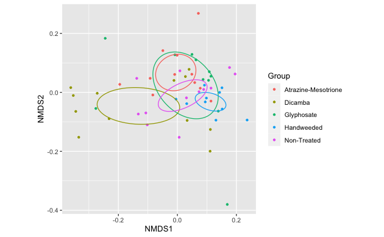

```r
T1_dmn<-ggordiplots::gg_ordiplot(ord = ord_t1_dmn, groups = data.frame(sample_data(subset_samples(ps_dmn, Time == "T1")))$Herbicide, choices = c(1, 2), kind = c("se"), conf = 0.95, show.groups = "all", ellipse = TRUE, label = FALSE, hull = FALSE, spiders = FALSE, plot = TRUE, pt.size = 1)
```

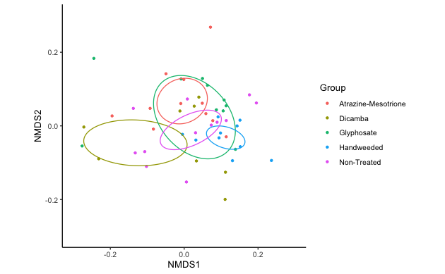

```r
T1_dmn$plot + theme_classic() + xlim(-0.3, 0.3) + ylim(-0.3, 0.3)

ggsave("/Users/gordoncuster/Desktop/Git_Projects/Herbicide_Microbes_PT1/Figures/16S_ordination_dmn_T1.pdf")
```

```r
ord_t2_dmn<-ordinate(physeq = subset_samples(ps_dmn, Time=="T2"), method = "NMDS", distance = "bray", k=3, trymax= 100)
```

```
*** Best solution repeated 8 times
```

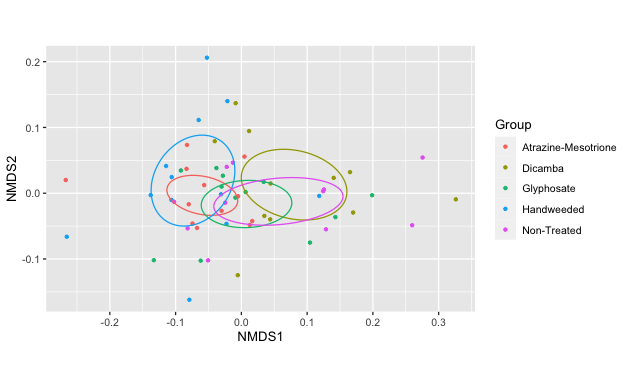

```r
T2_dmn<-ggordiplots::gg_ordiplot(ord = ord_t2_dmn, groups = data.frame(sample_data(subset_samples(ps_dmn, Time == "T2")))$Herbicide, choices = c(1, 2), kind = c("se"), conf = 0.95, show.groups = "all", ellipse = TRUE, label = FALSE, hull = FALSE, spiders = FALSE, plot = TRUE, pt.size = 1)
```

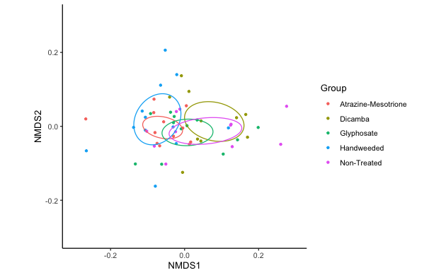

```r
T2_dmn$plot + theme_classic()+ xlim(-0.3, 0.3) + ylim(-0.3, 0.3)
ggsave("/Users/gordoncuster/Desktop/Git_Projects/Herbicide_Microbes_PT1/Figures/16S_ordination_dmn_T2.pdf")
```

```r
ord_t3_dmn<-ordinate(physeq = subset_samples(ps_dmn, Time=="T3"), method = "NMDS", distance = "bray", k=3, trymax= 100)
```

```
*** Best solution repeated 5 times
```

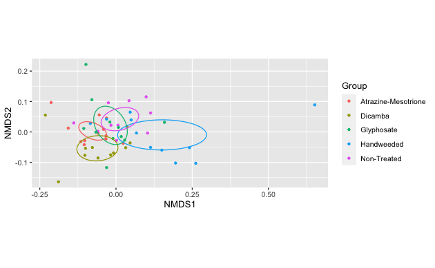

```r
T3_dmn<-ggordiplots::gg_ordiplot(ord = ord_t3_dmn, groups = data.frame(sample_data(subset_samples(ps_dmn, Time == "T3")))$Herbicide, choices = c(1, 2), kind = c("se"), conf = 0.95, show.groups = "all", ellipse = TRUE, label = FALSE, hull = FALSE, spiders = FALSE, plot = TRUE, pt.size = 1)
```

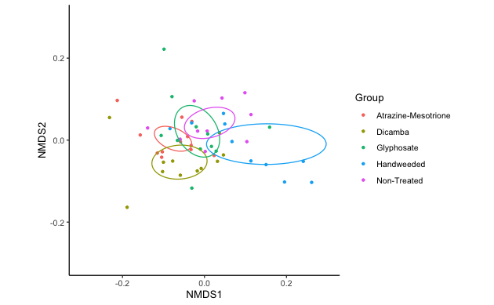

```r
T3_dmn$plot + theme_classic()+ xlim(-0.3, 0.3) + ylim(-0.3, 0.3)
ggsave("/Users/gordoncuster/Desktop/Git_Projects/Herbicide_Microbes_PT1/Figures/16S_ordination_dmn_T3.pdf")
```

Ordination plots rarefied

```r
ord_t1_rare<-ordinate(physeq = subset_samples(ps_rare, Time=="T1"), method = "NMDS", distance = "bray", k=3, trymax= 100)
```

```
Square root transformation
Wisconsin double standardization
*** Best solution repeated 1 times
```

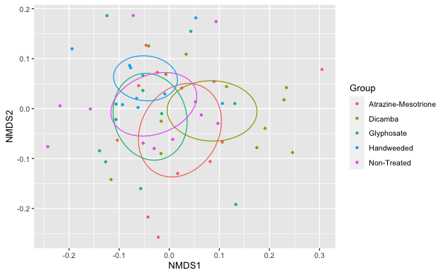

```r
T1_rare<-ggordiplots::gg_ordiplot(ord = ord_t1_rare, groups = data.frame(sample_data(subset_samples(ps_rare, Time == "T1")))$Herbicide, choices = c(1, 2), kind = c("se"), conf = 0.95, show.groups = "all", ellipse = TRUE, label = FALSE, hull = FALSE, spiders = FALSE, plot = TRUE, pt.size = 1)
```

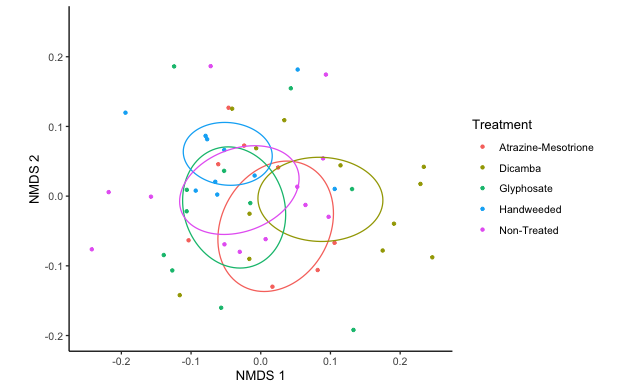

```r
T1_rare_plot<-T1_rare$plot + theme_classic() +  xlim(-0.25, 0.25) + ylim(-0.2, 0.25)  + guides(color=guide_legend("Treatment")) + xlab("NMDS 1") + ylab("NMDS 2")
T1_rare_plot
```

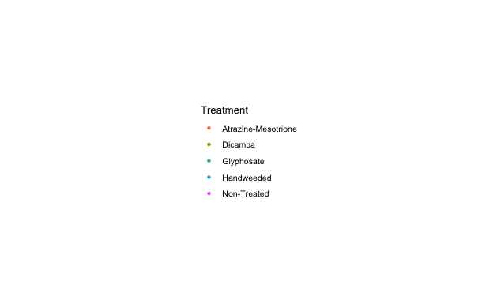

```r
library(cowplot)
my_legend <- get_legend(T1_rare_plot)
library(ggpubr)
as_ggplot(my_legend)
ggsave("/Users/gordoncuster/Desktop/Git_Projects/Herbicide_Microbes_PT1/Figures/FinalPlots/Individual Figures/16S_ordinationlegend.pdf")
```

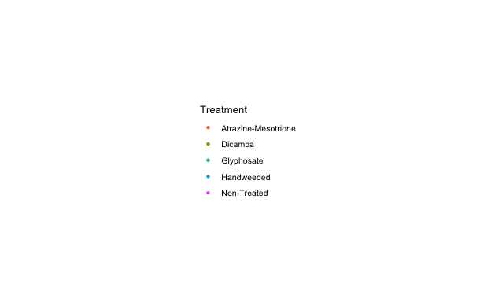

```r
as_ggplot(my_legend)
ggsave("/Users/gordoncuster/Desktop/Git_Projects/Herbicide_Microbes_PT1/Figures/FinalPlots/Individual Figures/16S_ordinationlegend.eps")
```

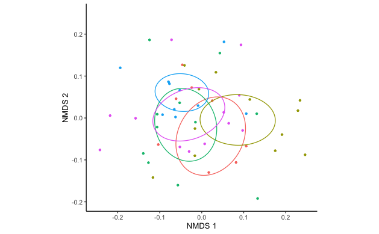

```r
T1_rare_plot<-T1_rare_plot + theme(legend.position = "none")
T1_rare_plot
ggsave("/Users/gordoncuster/Desktop/Git_Projects/Herbicide_Microbes_PT1/Figures/FinalPlots/Individual Figures/16S_ordination_rare_T1.pdf")
ggsave("/Users/gordoncuster/Desktop/Git_Projects/Herbicide_Microbes_PT1/Figures/FinalPlots/Individual Figures/16S_ordination_rare_T1.eps")
```

```r
ord_t2_rare<-ordinate(physeq = subset_samples(ps_rare, Time=="T2"), method = "NMDS", distance = "bray", k=3, trymax= 100)
```

```
Square root transformation
Wisconsin double standardization
*** Best solution was not repeated -- monoMDS stopping criteria:
    80: no. of iterations >= maxit
    20: stress ratio > sratmax
```

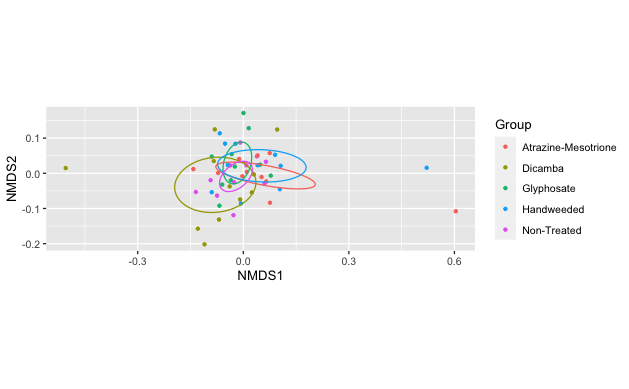

```r
T2_rare<-ggordiplots::gg_ordiplot(ord = ord_t2_rare, groups = data.frame(sample_data(subset_samples(ps_rare, Time == "T2")))$Herbicide, choices = c(1, 2), kind = c("se"), conf = 0.95, show.groups = "all", ellipse = TRUE, label = FALSE, hull = FALSE, spiders = FALSE, plot = TRUE, pt.size = 1)
```

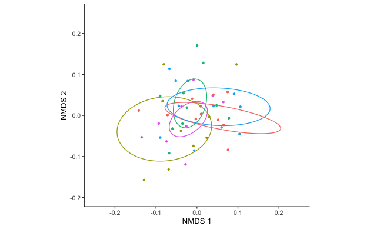

```r
T2_rare_plot<-T2_rare$plot + theme_classic() + xlim(-0.25, 0.25) + ylim(-0.2, 0.25)+ theme(legend.position = "none")  + xlab("NMDS 1") + ylab("NMDS 2")
T2_rare_plot
ggsave("/Users/gordoncuster/Desktop/Git_Projects/Herbicide_Microbes_PT1/Figures/FinalPlots/Individual Figures/16S_ordination_rare_T2.pdf")
ggsave("/Users/gordoncuster/Desktop/Git_Projects/Herbicide_Microbes_PT1/Figures/FinalPlots/Individual Figures/16S_ordination_rare_T2.eps")
```

```r
#G166SG identified as outlier based on plots with it included. Removed to create plot.
ps_rare <-  subset_samples(ps_rare, sample_names(ps_rare) != "G166SG")
ord_t3_rare<-ordinate(physeq = subset_samples(ps_rare, Time=="T3"), method = "NMDS", distance = "bray", k=3, trymax= 100)
```

```
Square root transformation
Wisconsin double standardization
*** Best solution repeated 3 times
```

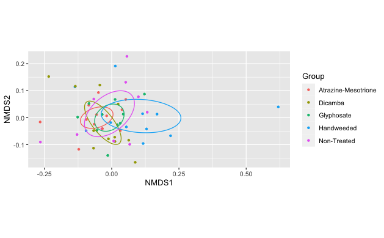

```r
T3_rare<-ggordiplots::gg_ordiplot(ord = ord_t3_rare, groups = data.frame(sample_data(subset_samples(ps_rare, Time == "T3")))$Herbicide, choices = c(1, 2), kind = c("se"), conf = 0.95, show.groups = "all", ellipse = TRUE, label = FALSE, hull = FALSE, spiders = FALSE, plot = TRUE, pt.size = 1)
```

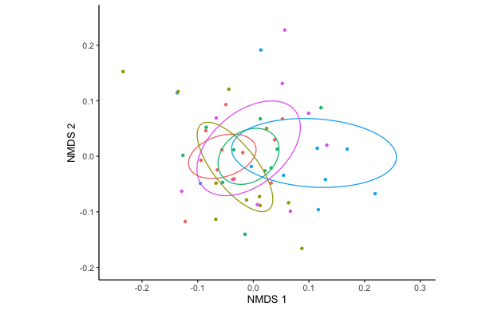

```r
T3_rare_plot<-T3_rare$plot + theme_classic() + xlim(-0.25, 0.3) + ylim(-0.2, 0.25) + theme(legend.position = "none")  + xlab("NMDS 1") + ylab("NMDS 2")
T3_rare_plot
ggsave("/Users/gordoncuster/Desktop/Git_Projects/Herbicide_Microbes_PT1/Figures/FinalPlots/Individual Figures/16S_ordination_rare_T3.pdf")
ggsave("/Users/gordoncuster/Desktop/Git_Projects/Herbicide_Microbes_PT1/Figures/FinalPlots/Individual Figures/16S_ordination_rare_T3.eps")
```

```r
#library(ggpubr)
#ggarrange(T1_rare_plot, T2_rare_plot, T3_rare_plot, ncol = 1)
#ggsave("/Users/gordoncuster/Desktop/Git_Projects/Herbicide_Microbes_PT1/Figures/16S_combined_ordination.pdf", width = 5, height = 10)
#ggsave("/Users/gordoncuster/Desktop/Git_Projects/Herbicide_Microbes_PT1/Figures/16S_combined_ordination.eps", width = 5, height = 10)
```

CAP ordination plots rarefied - not used

```
t1_dist <- distance(subset_samples(ps_rare, Time=="T1"), method="bray") #get wUnifrac and save
t1_table<-as.matrix(dist(t1_dist)) #transform wUnifrac index
ord_t1_rare_cap <- capscale(t1_table ~ Herbicide, data.frame(sample_data(subset_samples(ps_rare, Time == "T1"))))
T1_rare<-ggordiplots::gg_ordiplot(ord = ord_t1_rare_cap, groups = data.frame(sample_data(subset_samples(ps_rare, Time == "T1")))$Herbicide, choices = c(1, 2), kind = c("se"), conf = 0.95, show.groups = "all", ellipse = TRUE, label = FALSE, hull = FALSE, spiders = FALSE, plot = TRUE, pt.size = 1)
T1_rare$plot + theme_classic()
ggsave("/Users/gordoncuster/Desktop/Git_Projects/Herbicide_Microbes_PT1/Figures/16S_ordination_rare_T1_cap.pdf")


t2_dist <- distance(subset_samples(ps_rare, Time=="T2"), method="bray") #get wUnifrac and save
t2_table<-as.matrix(dist(t2_dist)) #transform wUnifrac index
ord_t2_rare_cap <- capscale(t2_table ~ Herbicide, data.frame(sample_data(subset_samples(ps_rare, Time == "T2"))))
T2_rare<-ggordiplots::gg_ordiplot(ord = ord_t2_rare_cap, groups = data.frame(sample_data(subset_samples(ps_rare, Time == "T2")))$Herbicide, choices = c(1, 2), kind = c("se"), conf = 0.95, show.groups = "all", ellipse = TRUE, label = FALSE, hull = FALSE, spiders = FALSE, plot = TRUE, pt.size = 1)
T2_rare$plot + theme_classic()
ggsave("/Users/gordoncuster/Desktop/Git_Projects/Herbicide_Microbes_PT1/Figures/16S_ordination_rare_T2_cap.pdf")


#G166SG identified as outlier based on plots with it included. Removed to create plot.
ps_rare <-  subset_samples(ps_rare, sample_names(ps_rare) != "G166SG")
t3_dist <- distance(subset_samples(ps_rare, Time=="T3"), method="bray") #get wUnifrac and save
t3_table<-as.matrix(dist(t3_dist)) #transform wUnifrac index
ord_t3_rare_cap <- capscale(t3_table ~ Herbicide, data.frame(sample_data(subset_samples(ps_rare, Time == "T3"))))
T3_rare<-ggordiplots::gg_ordiplot(ord = ord_t3_rare_cap, groups = data.frame(sample_data(subset_samples(ps_rare, Time == "T3")))$Herbicide, choices = c(1, 2), kind = c("se"), conf = 0.95, show.groups = "all", ellipse = TRUE, label = FALSE, hull = FALSE, spiders = FALSE, plot = TRUE, pt.size = 1)
T3_rare$plot + theme_classic()
ggsave("/Users/gordoncuster/Desktop/Git_Projects/Herbicide_Microbes_PT1/Figures/16S_ordination_rare_T3_cap.pdf")
ggplot_build(T3_rare$plot)$data
```

Pairwise adonis testing

```r
ps_pairwiseadonis<-function(physeq){
  otu_tab<-data.frame(phyloseq::otu_table(physeq))
  md_tab<-data.frame(phyloseq::sample_data(physeq))
    if(taxa_are_rows(physeq)== T){
       physeq_dist<-parallelDist::parDist(as.matrix(t(otu_tab)), method = "bray")}
            else{physeq_dist<-parallelDist::parDist(as.matrix(otu_tab), method = "bray")}
pairwiseAdonis::pairwise.adonis(x = physeq_dist, factors = md_tab$Herbicide, p.adjust.m = "none", perm = 1000)
}

ps_t1<-subset_samples(ps_rare_sub, Time == "T1")
ps_t1<-prune_taxa(taxa_sums(ps_t1) > 2, ps_t1)

ps_t2<-subset_samples(ps_rare_sub, Time == "T2")
ps_t2<-prune_taxa(taxa_sums(ps_t2) > 2, ps_t2)

ps_t3<-subset_samples(ps_rare_sub, Time == "T3")
ps_t3<-prune_taxa(taxa_sums(ps_t3) > 2, ps_t3)


ps_pairwiseadonis(ps_t1)
```

| pairs | Df | SumsOfSqs | F.Model | R2 | p.value | p.adjusted | sig |
| --- | --- | --- | --- | --- | --- | --- | --- |
| Dicamba vs Handweeded | 1 | 0.2659335 | 1.6259599 | 0.07518556 | 0.01298701 | 0.01298701 | . |
| Dicamba vs Non-Treated | 1 | 0.1984051 | 1.1966682 | 0.05158793 | 0.10489510 | 0.10489510 |  |
| Dicamba vs Atrazine-Mesotrione | 1 | 0.1853632 | 1.0911379 | 0.04939256 | 0.20079920 | 0.20079920 |  |
| Dicamba vs Glyphosate | 1 | 0.2285380 | 1.3425631 | 0.06008993 | 0.05294705 | 0.05294705 |  |
| Handweeded vs Non-Treated | 1 | 0.1573391 | 0.9884215 | 0.04709366 | 0.48451548 | 0.48451548 |  |
| Handweeded vs Atrazine-Mesotrione | 1 | 0.2144353 | 1.3127638 | 0.06462753 | 0.01398601 | 0.01398601 | . |
| Handweeded vs Glyphosate | 1 | 0.1813832 | 1.1078379 | 0.05509483 | 0.13486513 | 0.13486513 |  |
| Non-Treated vs Atrazine-Mesotrione | 1 | 0.1628584 | 0.9827541 | 0.04470568 | 0.49150849 | 0.49150849 |  |
| Non-Treated vs Glyphosate | 1 | 0.1647693 | 0.9922227 | 0.04511698 | 0.45054945 | 0.45054945 |  |
| Atrazine-Mesotrione vs Glyphosate | 1 | 0.1739159 | 1.0208681 | 0.04856451 | 0.34265734 | 0.34265734 |  |

```r
ps_pairwiseadonis(ps_t2)
```

[output not shown]

Pairwise betadispr by treatment, time and mode

```r
ps_betadispr<-function(physeq, groupingvar = "Groupingvar"){
  otu_tab<-data.frame(phyloseq::otu_table(physeq))
  md_tab<-data.frame(phyloseq::sample_data(physeq))
    if(taxa_are_rows(physeq)== T){
       physeq_dist<-parallelDist::parDist(as.matrix(t(otu_tab)), method = "bray")}
            else{physeq_dist<-parallelDist::parDist(as.matrix(otu_tab), method = "bray")}
                mod<-vegan::betadisper(physeq_dist, md_tab[,groupingvar])
        ## Perform test
                print(anova(mod))
        ## Permutation test for F
                pmod <- vegan::permutest(mod, permutations = 1000, pairwise = TRUE)
                print(pmod)
                print(boxplot(mod))
}
```

permute test of disperson

```
Analysis of Variance Table

Response: Distances
          Df   Sum Sq   Mean Sq F value    Pr(>F)
Groups     2 0.010804 0.0054021  11.752 5.966e-05 ***
Residuals 53 0.024363 0.0004597
---
Signif. codes:  0 ‘***’ 0.001 ‘**’ 0.01 ‘*’ 0.05 ‘.’ 0.1 ‘ ’ 1

Permutation test for homogeneity of multivariate dispersions
Permutation: free
Number of permutations: 1000

Response: Distances
          Df   Sum Sq   Mean Sq      F N.Perm   Pr(>F)
Groups     2 0.010804 0.0054021 11.752   1000 0.000999 ***
Residuals 53 0.024363 0.0004597
---
Signif. codes:  0 ‘***’ 0.001 ‘**’ 0.01 ‘*’ 0.05 ‘.’ 0.1 ‘ ’ 1

Pairwise comparisons:
(Observed p-value below diagonal, permuted p-value above diagonal)
              Chemical       Hand Non-Treated
Chemical               0.00099900      0.0030
Hand        0.00014786                 0.2288
Non-Treated 0.00224710 0.23207124
$stats
          [,1]      [,2]      [,3]
[1,] 0.3804321 0.3504290 0.3665005
[2,] 0.3977447 0.3647856 0.3788662
[3,] 0.4169569 0.3742943 0.3945778
[4,] 0.4264042 0.4009722 0.4033251
[5,] 0.4454283 0.4306733 0.4230861

$n
[1] 34 10 12

$conf
          [,1]      [,2]      [,3]
[1,] 0.4091911 0.3562140 0.3834219
[2,] 0.4247227 0.3923745 0.4057337

$out
   G046SG
0.4892527

$group
[1] 1

$names
[1] "Chemical"    "Hand"        "Non-Treated"
```

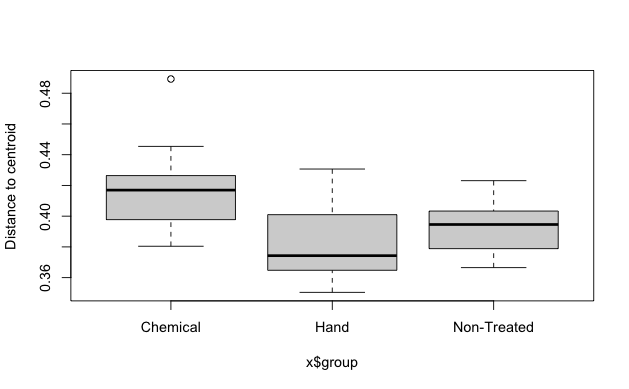

```r
ps_betadispr(subset_samples(ps_rare_sub, Time == "T1"), groupingvar = "Mode")
```

```
Analysis of Variance Table

Response: Distances
          Df   Sum Sq   Mean Sq F value  Pr(>F)
Groups     2 0.005564 0.0027818  2.6163 0.08286 .
Residuals 51 0.054227 0.0010633
---
Signif. codes:  0 ‘***’ 0.001 ‘**’ 0.01 ‘*’ 0.05 ‘.’ 0.1 ‘ ’ 1

Permutation test for homogeneity of multivariate dispersions
Permutation: free
Number of permutations: 1000

Response: Distances
          Df   Sum Sq   Mean Sq      F N.Perm  Pr(>F)
Groups     2 0.005564 0.0027818 2.6163   1000 0.08392 .
Residuals 51 0.054227 0.0010633
---
Signif. codes:  0 ‘***’ 0.001 ‘**’ 0.01 ‘*’ 0.05 ‘.’ 0.1 ‘ ’ 1

Pairwise comparisons:
(Observed p-value below diagonal, permuted p-value above diagonal)
            Chemical     Hand Non-Treated
Chemical             0.576424      0.0170
Hand        0.544593               0.2288
Non-Treated 0.016124 0.196261
$stats
          [,1]      [,2]      [,3]
[1,] 0.3663187 0.3540293 0.3405369
[2,] 0.3828402 0.3788455 0.3696567
[3,] 0.3940453 0.3912101 0.3843606
[4,] 0.4182627 0.4028680 0.3904450
[5,] 0.4630042 0.4051548 0.4046331

$n
[1] 32 11 11

$conf
          [,1]      [,2]      [,3]
[1,] 0.3841516 0.3797660 0.3744573
[2,] 0.4039391 0.4026541 0.3942639

$out
   G070SG    G065SG
0.5218521 0.5170988

$group
[1] 1 2

$names
[1] "Chemical"    "Hand"        "Non-Treated"
```

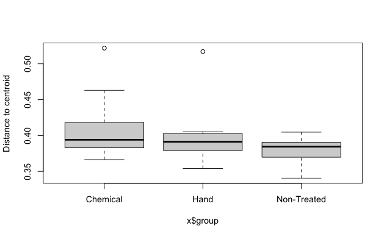

```r
ps_betadispr(subset_samples(ps_rare_sub, Time == "T2"), groupingvar = "Mode")
```

```
Analysis of Variance Table

Response: Distances
          Df   Sum Sq    Mean Sq F value Pr(>F)
Groups     2 0.000037 0.00001841  0.0189 0.9813
Residuals 51 0.049706 0.00097462

Permutation test for homogeneity of multivariate dispersions
Permutation: free
Number of permutations: 1000

Response: Distances
          Df   Sum Sq    Mean Sq      F N.Perm Pr(>F)
Groups     2 0.000037 0.00001841 0.0189   1000  0.987
Residuals 51 0.049706 0.00097462

Pairwise comparisons:
(Observed p-value below diagonal, permuted p-value above diagonal)
            Chemical    Hand Non-Treated
Chemical             0.95405      0.8412
Hand         0.95042              0.9341
Non-Treated  0.81436 0.93161
$stats
          [,1]      [,2]      [,3]
[1,] 0.3660073 0.3529787 0.3641228
[2,] 0.3775720 0.3619575 0.3888203
[3,] 0.3938294 0.3833167 0.3943978
[4,] 0.4094830 0.4127647 0.4146763
[5,] 0.4548827 0.4517078 0.4523815

$n
[1] 33 11 10

$conf
          [,1]      [,2]      [,3]
[1,] 0.3850526 0.3591128 0.3814792
[2,] 0.4026063 0.4075206 0.4073165

$out
   G123SG    G125SG
0.4884281 0.5089781

$group
[1] 1 2

$names
[1] "Chemical"    "Hand"        "Non-Treated"
```

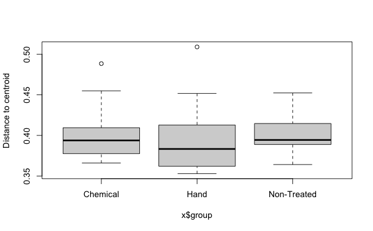

```r
ps_betadispr(subset_samples(ps_rare_sub, Time == "T3"), groupingvar = "Mode")
```

```
Analysis of Variance Table

Response: Distances
          Df   Sum Sq    Mean Sq F value  Pr(>F)
Groups     2 0.005636 0.00281822  3.8869 0.02381 *
Residuals 96 0.069606 0.00072506
---
Signif. codes:  0 ‘***’ 0.001 ‘**’ 0.01 ‘*’ 0.05 ‘.’ 0.1 ‘ ’ 1

Permutation test for homogeneity of multivariate dispersions
Permutation: free
Number of permutations: 1000

Response: Distances
          Df   Sum Sq    Mean Sq      F N.Perm  Pr(>F)
Groups     2 0.005636 0.00281822 3.8869   1000 0.02398 *
Residuals 96 0.069606 0.00072506
---
Signif. codes:  0 ‘***’ 0.001 ‘**’ 0.01 ‘*’ 0.05 ‘.’ 0.1 ‘ ’ 1

Pairwise comparisons:
(Observed p-value below diagonal, permuted p-value above diagonal)
          T1        T2     T3
T1           0.2087912 0.0030
T2 0.1962534           0.2018
T3 0.0023253 0.1971546
$stats
          [,1]      [,2]      [,3]
[1,] 0.3804400 0.3663109 0.3660212
[2,] 0.3977547 0.3828261 0.3776147
[3,] 0.4169648 0.3940558 0.3939165
[4,] 0.4264004 0.4182577 0.4094472
[5,] 0.4454327 0.4630282 0.4548610

$n
[1] 34 32 33

$conf
          [,1]      [,2]      [,3]
[1,] 0.4092027 0.3841594 0.3851612
[2,] 0.4247268 0.4039521 0.4026718

$out
   G046SG    G070SG    G123SG
0.4892518 0.5218707 0.4883976

$group
[1] 1 2 3

$names
[1] "T1" "T2" "T3"
```

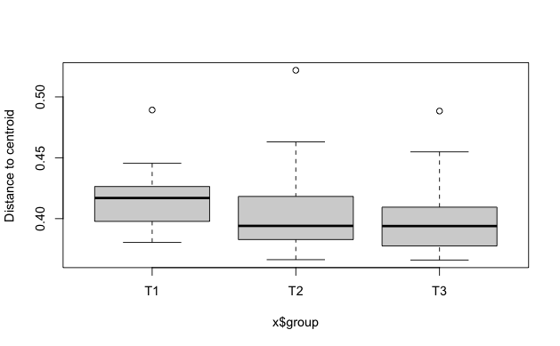

```r
ps_betadispr(subset_samples(ps_rare_sub, Mode == "Chemical"), groupingvar = "Time")
```

```
Analysis of Variance Table

Response: Distances
          Df    Sum Sq    Mean Sq F value Pr(>F)
Groups     2 0.0019364 0.00096822  2.4191 0.1062
Residuals 30 0.0120071 0.00040024

Permutation test for homogeneity of multivariate dispersions
Permutation: free
Number of permutations: 1000

Response: Distances
          Df    Sum Sq    Mean Sq      F N.Perm Pr(>F)
Groups     2 0.0019364 0.00096822 2.4191   1000 0.1119
Residuals 30 0.0120071 0.00040024

Pairwise comparisons:
(Observed p-value below diagonal, permuted p-value above diagonal)
         T1       T2     T3
T1          0.106893 0.5215
T2 0.099548          0.0519
T3 0.496758 0.059679
$stats
          [,1]      [,2]      [,3]
[1,] 0.3665168 0.3405704 0.3641416
[2,] 0.3788611 0.3696647 0.3888093
[3,] 0.3945750 0.3843826 0.3943811
[4,] 0.4033384 0.3904236 0.4146615
[5,] 0.4230848 0.4046057 0.4524094

$n
[1] 12 11 10

$conf
          [,1]      [,2]      [,3]
[1,] 0.3834107 0.3744933 0.3814644
[2,] 0.4057392 0.3942719 0.4072979

$out
numeric(0)

$group
numeric(0)

$names
[1] "T1" "T2" "T3"
```

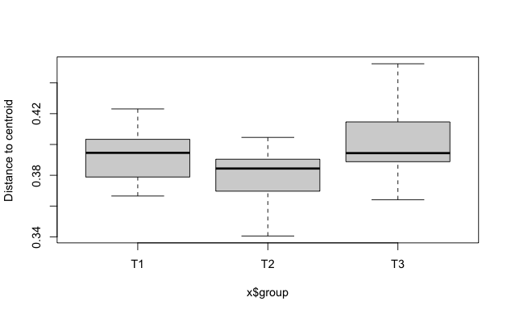

```r
ps_betadispr(subset_samples(ps_rare_sub, Mode == "Non-Treated"), groupingvar = "Time")
```

```
Analysis of Variance Table

Response: Distances
          Df   Sum Sq    Mean Sq F value Pr(>F)
Groups     2 0.001904 0.00095187  0.5916   0.56
Residuals 29 0.046661 0.00160901

Permutation test for homogeneity of multivariate dispersions
Permutation: free
Number of permutations: 1000

Response: Distances
          Df   Sum Sq    Mean Sq      F N.Perm Pr(>F)
Groups     2 0.001904 0.00095187 0.5916   1000 0.6014
Residuals 29 0.046661 0.00160901

Pairwise comparisons:
(Observed p-value below diagonal, permuted p-value above diagonal)
        T1      T2     T3
T1         0.34166 0.3876
T2 0.27871         0.9461
T3 0.35755 0.94959
$stats
          [,1]      [,2]      [,3]
[1,] 0.3504614 0.3540454 0.3530162
[2,] 0.3647810 0.3788398 0.3619277
[3,] 0.3742906 0.3912157 0.3833179
[4,] 0.4009630 0.4028635 0.4127718
[5,] 0.4306622 0.4051523 0.4516826

$n
[1] 10 11 11

$conf
          [,1]      [,2]      [,3]
[1,] 0.3562127 0.3797711 0.3590964
[2,] 0.3923686 0.4026603 0.4075394

$out
   G065SG    G125SG
0.5171023 0.5089702

$group
[1] 2 3

$names
[1] "T1" "T2" "T3"
```

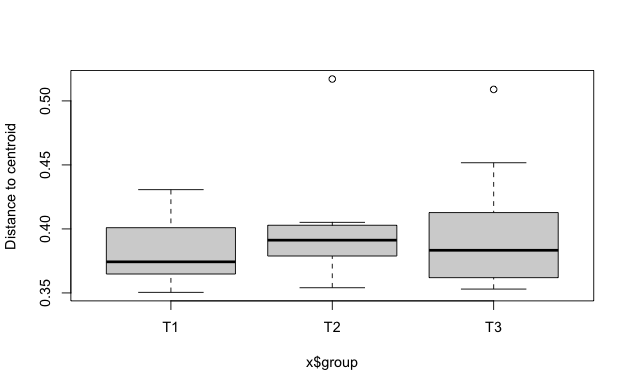

```r
ps_betadispr(subset_samples(ps_rare_sub, Mode == "Hand"), groupingvar = "Time")
```

```
Analysis of Variance Table

Response: Distances
          Df   Sum Sq    Mean Sq F value Pr(>F)
Groups     4 0.002840 0.00070997   1.074 0.3791
Residuals 51 0.033714 0.00066106

Permutation test for homogeneity of multivariate dispersions
Permutation: free
Number of permutations: 1000

Response: Distances
          Df   Sum Sq    Mean Sq     F N.Perm Pr(>F)
Groups     4 0.002840 0.00070997 1.074   1000 0.3886
Residuals 51 0.033714 0.00066106

Pairwise comparisons:
(Observed p-value below diagonal, permuted p-value above diagonal)
                    Atrazine-Mesotrione  Dicamba Glyphosate Handweeded Non-Treated
Atrazine-Mesotrione                     0.932068   0.972028   0.073926      0.3776
Dicamba                        0.930200            0.974026   0.102897      0.3966
Glyphosate                     0.967636 0.975250              0.167832      0.5135
Handweeded                     0.079155 0.109142   0.175310                 0.2118
Non-Treated                    0.369597 0.406696   0.506436   0.232071
$stats
          [,1]      [,2]      [,3]      [,4]      [,5]
[1,] 0.3667119 0.3551354 0.3573486 0.3504290 0.3665005
[2,] 0.3836426 0.3774236 0.3790031 0.3647856 0.3788662
[3,] 0.4069157 0.4021368 0.3897409 0.3742943 0.3945778
[4,] 0.4088518 0.4231790 0.4188086 0.4009722 0.4033251
[5,] 0.4393221 0.4426598 0.4302367 0.4306733 0.4230861

$n
[1] 11 12 11 10 12

$conf
          [,1]      [,2]      [,3]      [,4]      [,5]
[1,] 0.3949063 0.3812674 0.3707780 0.3562140 0.3834219
[2,] 0.4189251 0.4230061 0.4087038 0.3923745 0.4057337

$out
   G046SG
0.4804066

$group
[1] 3

$names
[1] "Atrazine-Mesotrione" "Dicamba"             "Glyphosate"          "Handweeded"          "Non-Treated"
```

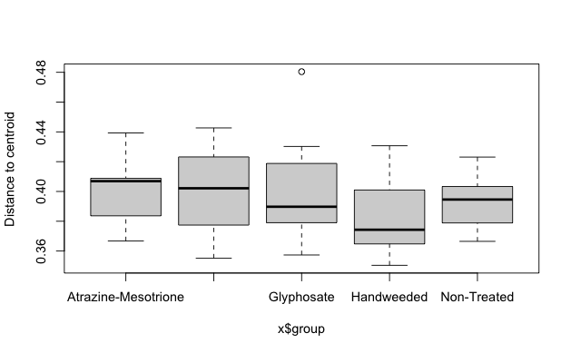

```r
ps_betadispr(subset_samples(ps_rare_sub, Time == "T1"), groupingvar = "Herbicide")
```

```
Analysis of Variance Table

Response: Distances
          Df   Sum Sq    Mean Sq F value Pr(>F)
Groups     4 0.002843 0.00071079  0.6541 0.6268
Residuals 49 0.053249 0.00108672

Permutation test for homogeneity of multivariate dispersions
Permutation: free
Number of permutations: 1000

Response: Distances
          Df   Sum Sq    Mean Sq      F N.Perm Pr(>F)
Groups     4 0.002843 0.00071079 0.6541   1000 0.6134
Residuals 49 0.053249 0.00108672

Pairwise comparisons:
(Observed p-value below diagonal, permuted p-value above diagonal)
                    Atrazine-Mesotrione  Dicamba Glyphosate Handweeded Non-Treated
Atrazine-Mesotrione                     0.741259   0.694306   0.741259      0.3876
Dicamba                        0.727584            0.314685   0.961039      0.0949
Glyphosate                     0.640120 0.282922              0.394605      0.6064
Handweeded                     0.734970 0.963589   0.382841                 0.1908
Non-Treated                    0.393767 0.097876   0.590421   0.196261
$stats
          [,1]      [,2]      [,3]      [,4]      [,5]
[1,] 0.3474546 0.3612943 0.3592504 0.3540293 0.3405369
[2,] 0.3649680 0.3733844 0.3708470 0.3788455 0.3696567
[3,] 0.3810085 0.3939371 0.3751855 0.3912101 0.3843606
[4,] 0.4036468 0.4158683 0.4004167 0.4028680 0.3904450
[5,] 0.4120948 0.4539607 0.4344526 0.4051548 0.4046331

$n
[1] 11 11 10 11 11

$conf
          [,1]      [,2]      [,3]      [,4]      [,5]
[1,] 0.3625824 0.3736982 0.3604113 0.3797660 0.3744573
[2,] 0.3994346 0.4141759 0.3899598 0.4026541 0.3942639

$out
   G070SG    G065SG
0.5064339 0.5170988

$group
[1] 1 4

$names
[1] "Atrazine-Mesotrione" "Dicamba"             "Glyphosate"          "Handweeded"          "Non-Treated"
```

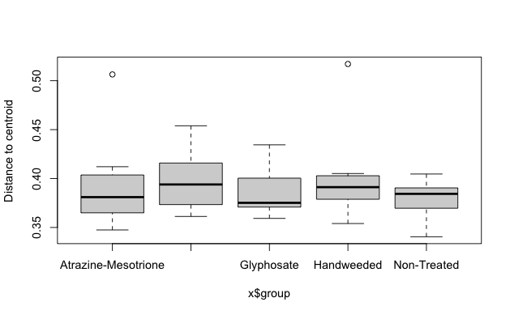

```r
ps_betadispr(subset_samples(ps_rare_sub, Time == "T2"), groupingvar = "Herbicide")
```

```
Analysis of Variance Table

Response: Distances
          Df   Sum Sq    Mean Sq F value Pr(>F)
Groups     4 0.003957 0.00098924  1.0438 0.3944
Residuals 49 0.046441 0.00094777

Permutation test for homogeneity of multivariate dispersions
Permutation: free
Number of permutations: 1000

Response: Distances
          Df   Sum Sq    Mean Sq      F N.Perm Pr(>F)
Groups     4 0.003957 0.00098924 1.0438   1000 0.4076
Residuals 49 0.046441 0.00094777

Pairwise comparisons:
(Observed p-value below diagonal, permuted p-value above diagonal)
                    Atrazine-Mesotrione  Dicamba Glyphosate Handweeded Non-Treated
Atrazine-Mesotrione                     0.387612   0.700300   0.305694      0.1049
Dicamba                        0.355725            0.201798   0.757243      0.6064
Glyphosate                     0.696633 0.191707              0.240759      0.0360
Handweeded                     0.305819 0.741563   0.222883                 0.9381
Non-Treated                    0.107926 0.561747   0.033811   0.931610
$stats
          [,1]      [,2]      [,3]      [,4]      [,5]
[1,] 0.3541179 0.3627381 0.3520382 0.3529787 0.3641228
[2,] 0.3639605 0.3754509 0.3633215 0.3619575 0.3888203
[3,] 0.3735777 0.3869820 0.3798037 0.3833167 0.3943978
[4,] 0.3928099 0.3954294 0.3890832 0.4127647 0.4146763
[5,] 0.4082574 0.4037548 0.4035468 0.4517078 0.4523815

$n
[1] 12 11 10 11 10

$conf
          [,1]      [,2]      [,3]      [,4]      [,5]
[1,] 0.3604193 0.3774645 0.3669321 0.3591128 0.3814792
[2,] 0.3867361 0.3964996 0.3926753 0.4075206 0.4073165

$out
   G131SG    G123SG    G125SG
0.4392663 0.4725323 0.5089781

$group
[1] 1 2 4

$names
[1] "Atrazine-Mesotrione" "Dicamba"             "Glyphosate"          "Handweeded"          "Non-Treated"
```

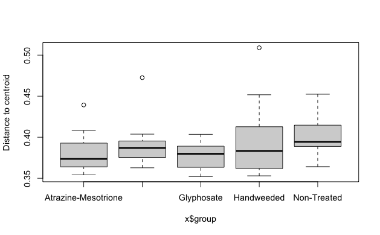

```r
ps_betadispr(subset_samples(ps_rare_sub, Time == "T3"), groupingvar = "Herbicide")
```

```
Analysis of Variance Table

Response: Distances
          Df    Sum Sq    Mean Sq F value Pr(>F)
Groups     2 0.0028576 0.00142878  2.0791 0.1439
Residuals 28 0.0192418 0.00068721

Permutation test for homogeneity of multivariate dispersions
Permutation: free
Number of permutations: 1000

Response: Distances
          Df    Sum Sq    Mean Sq      F N.Perm Pr(>F)
Groups     2 0.0028576 0.00142878 2.0791   1000 0.1349
Residuals 28 0.0192418 0.00068721

Pairwise comparisons:
(Observed p-value below diagonal, permuted p-value above diagonal)
         T1       T2     T3
T1          0.266733 0.0739
T2 0.260682          0.4196
T3 0.071566 0.402183
$stats
          [,1]      [,2]      [,3]
[1,] 0.3573164 0.3592595 0.3520475
[2,] 0.3789992 0.3708523 0.3633372
[3,] 0.3897552 0.3751867 0.3798028
[4,] 0.4188308 0.4004023 0.3890938
[5,] 0.4302344 0.4344627 0.4035369

$n
[1] 11 10 10

$conf
          [,1]      [,2]      [,3]
[1,] 0.3707798 0.3604224 0.3669337
[2,] 0.4087305 0.3899511 0.3926719

$out
   G046SG
0.4803861

$group
[1] 1

$names
[1] "T1" "T2" "T3"
```

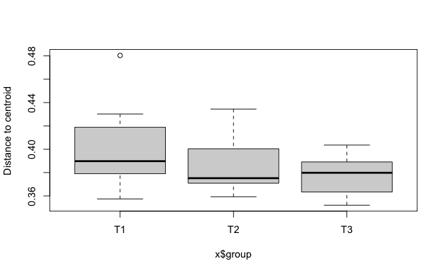

```r
ps_betadispr(subset_samples(ps_rare_sub, Herbicide == "Glyphosate"), groupingvar = "Time")
```

```
Analysis of Variance Table

Response: Distances
          Df    Sum Sq    Mean Sq F value Pr(>F)
Groups     2 0.0020678 0.00103388  1.0923  0.348
Residuals 31 0.0293417 0.00094651

Permutation test for homogeneity of multivariate dispersions
Permutation: free
Number of permutations: 1000

Response: Distances
          Df    Sum Sq    Mean Sq      F N.Perm Pr(>F)
Groups     2 0.0020678 0.00103388 1.0923   1000 0.3387
Residuals 31 0.0293417 0.00094651

Pairwise comparisons:
(Observed p-value below diagonal, permuted p-value above diagonal)
         T1       T2     T3
T1          0.645355 0.0549
T2 0.613621          0.4346
T3 0.059278 0.439855
$stats
          [,1]      [,2]      [,3]
[1,] 0.3667106 0.3474538 0.3540744
[2,] 0.3836487 0.3649640 0.3639284
[3,] 0.4069173 0.3810218 0.3735603
[4,] 0.4088534 0.4036548 0.3928858
[5,] 0.4393202 0.4120929 0.4082313

$n
[1] 11 11 12

$conf
          [,1]      [,2]      [,3]
[1,] 0.3949101 0.3625900 0.3603526
[2,] 0.4189245 0.3994537 0.3867680

$out
   G070SG    G131SG
0.5064274 0.4391984

$group
[1] 2 3

$names
[1] "T1" "T2" "T3"
```

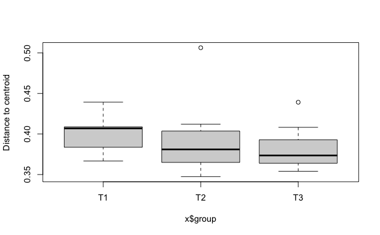

```r
ps_betadispr(subset_samples(ps_rare_sub, Herbicide == "Atrazine-Mesotrione"), groupingvar = "Time")
```

```
Analysis of Variance Table

Response: Distances
          Df    Sum Sq    Mean Sq F value Pr(>F)
Groups     2 0.0004756 0.00023778  0.2821 0.7561
Residuals 31 0.0261290 0.00084287

Permutation test for homogeneity of multivariate dispersions
Permutation: free
Number of permutations: 1000

Response: Distances
          Df    Sum Sq    Mean Sq      F N.Perm Pr(>F)
Groups     2 0.0004756 0.00023778 0.2821   1000 0.7582
Residuals 31 0.0261290 0.00084287

Pairwise comparisons:
(Observed p-value below diagonal, permuted p-value above diagonal)
        T1      T2     T3
T1         0.80819 0.4695
T2 0.82200         0.6234
T3 0.46827 0.62758
$stats
          [,1]      [,2]      [,3]
[1,] 0.3551246 0.3612819 0.3627463
[2,] 0.3774302 0.3733980 0.3754452
[3,] 0.4021407 0.3938902 0.3869939
[4,] 0.4231764 0.4158655 0.3954270
[5,] 0.4426504 0.4539101 0.4037696

$n
[1] 12 11 11

$conf
          [,1]      [,2]      [,3]
[1,] 0.3812756 0.3736592 0.3774747
[2,] 0.4230059 0.4141212 0.3965130

$out
   G123SG
0.4725292

$group
[1] 3

$names
[1] "T1" "T2" "T3"
```

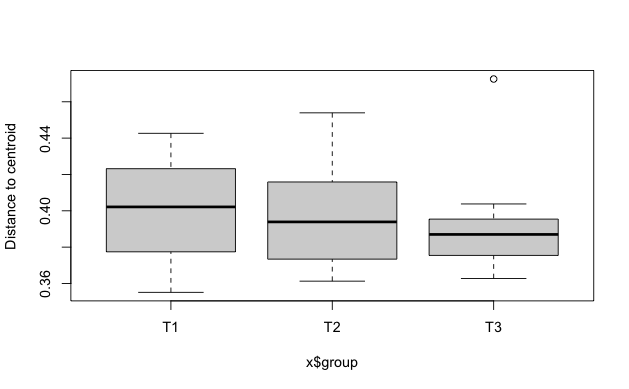

```r
ps_betadispr(subset_samples(ps_rare_sub, Herbicide == "Dicamba"), groupingvar = "Time")
```

```
Analysis of Variance Table

Response: Distances
          Df   Sum Sq    Mean Sq F value Pr(>F)
Groups     2 0.001904 0.00095187  0.5916   0.56
Residuals 29 0.046661 0.00160901

Permutation test for homogeneity of multivariate dispersions
Permutation: free
Number of permutations: 1000

Response: Distances
          Df   Sum Sq    Mean Sq      F N.Perm Pr(>F)
Groups     2 0.001904 0.00095187 0.5916   1000 0.5724
Residuals 29 0.046661 0.00160901

Pairwise comparisons:
(Observed p-value below diagonal, permuted p-value above diagonal)
        T1      T2     T3
T1         0.31469 0.4006
T2 0.27871         0.9520
T3 0.35755 0.94959
$stats
          [,1]      [,2]      [,3]
[1,] 0.3504614 0.3540454 0.3530162
[2,] 0.3647810 0.3788398 0.3619277
[3,] 0.3742906 0.3912157 0.3833179
[4,] 0.4009630 0.4028635 0.4127718
[5,] 0.4306622 0.4051523 0.4516826

$n
[1] 10 11 11

$conf
          [,1]      [,2]      [,3]
[1,] 0.3562127 0.3797711 0.3590964
[2,] 0.3923686 0.4026603 0.4075394

$out
   G065SG    G125SG
0.5171023 0.5089702

$group
[1] 2 3

$names
[1] "T1" "T2" "T3"
```

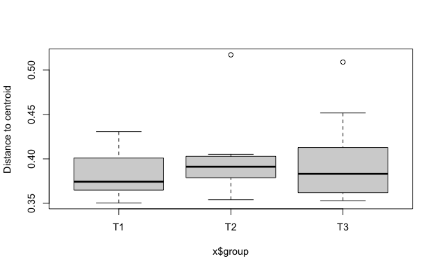

```r
ps_betadispr(subset_samples(ps_rare_sub, Herbicide == "Handweeded"), groupingvar = "Time")
```

```
Analysis of Variance Table

Response: Distances
          Df    Sum Sq    Mean Sq F value Pr(>F)
Groups     2 0.0019364 0.00096822  2.4191 0.1062
Residuals 30 0.0120071 0.00040024

Permutation test for homogeneity of multivariate dispersions
Permutation: free
Number of permutations: 1000

Response: Distances
          Df    Sum Sq    Mean Sq      F N.Perm  Pr(>F)
Groups     2 0.0019364 0.00096822 2.4191   1000 0.08991 .
Residuals 30 0.0120071 0.00040024
---
Signif. codes:  0 ‘***’ 0.001 ‘**’ 0.01 ‘*’ 0.05 ‘.’ 0.1 ‘ ’ 1

Pairwise comparisons:
(Observed p-value below diagonal, permuted p-value above diagonal)
         T1       T2     T3
T1          0.102897 0.5005
T2 0.099548          0.0549
T3 0.496758 0.059679
$stats
          [,1]      [,2]      [,3]
[1,] 0.3665168 0.3405704 0.3641416
[2,] 0.3788611 0.3696647 0.3888093
[3,] 0.3945750 0.3843826 0.3943811
[4,] 0.4033384 0.3904236 0.4146615
[5,] 0.4230848 0.4046057 0.4524094

$n
[1] 12 11 10

$conf
          [,1]      [,2]      [,3]
[1,] 0.3834107 0.3744933 0.3814644
[2,] 0.4057392 0.3942719 0.4072979

$out
numeric(0)

$group
numeric(0)

$names
[1] "T1" "T2" "T3"
```

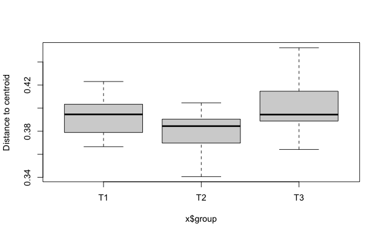

```r
ps_betadispr(subset_samples(ps_rare_sub, Herbicide == "Non-Treated"), groupingvar = "Time")
```

```
Analysis of Variance Table

Response: Distances
           Df   Sum Sq    Mean Sq F value Pr(>F)
Groups      4 0.003022 0.00075548  0.8548 0.4926
Residuals 159 0.140523 0.00088379

Permutation test for homogeneity of multivariate dispersions
Permutation: free
Number of permutations: 1000

Response: Distances
           Df   Sum Sq    Mean Sq      F N.Perm Pr(>F)
Groups      4 0.003022 0.00075548 0.8548   1000 0.4885
Residuals 159 0.140523 0.00088379

Pairwise comparisons:
(Observed p-value below diagonal, permuted p-value above diagonal)
                    Atrazine-Mesotrione Dicamba Glyphosate Handweeded Non-Treated
Atrazine-Mesotrione                     0.27972    0.72028    0.44356      0.8831
Dicamba                         0.27184            0.11089    0.88611      0.1219
Glyphosate                      0.73022 0.10681               0.26174      0.7982
Handweeded                      0.45118 0.88577    0.27400                 0.3347
Non-Treated                     0.87491 0.12162    0.79878    0.31930
$stats
          [,1]      [,2]      [,3]      [,4]      [,5]
[1,] 0.3635263 0.3726987 0.3644354 0.3712730 0.3653358
[2,] 0.3806232 0.3917390 0.3838596 0.3907178 0.3894408
[3,] 0.3980967 0.4079200 0.3980853 0.3985758 0.4017338
[4,] 0.4199957 0.4233531 0.4072361 0.4212779 0.4126745
[5,] 0.4700021 0.4662951 0.4375529 0.4411483 0.4390542

$n
[1] 34 34 31 32 33

$conf
          [,1]      [,2]      [,3]      [,4]      [,5]
[1,] 0.3874280 0.3993536 0.3914516 0.3900402 0.3953436
[2,] 0.4087653 0.4164864 0.4047190 0.4071115 0.4081241

$out
   G070SG    G123SG    G046SG    G076SG    G065SG    G125SG    G151SG
0.5184955 0.4995460 0.4894611 0.4554918 0.5311635 0.5552741 0.4631531

$group
[1] 1 2 3 3 4 4 5

$names
[1] "Atrazine-Mesotrione" "Dicamba"             "Glyphosate"          "Handweeded"          "Non-Treated"
```

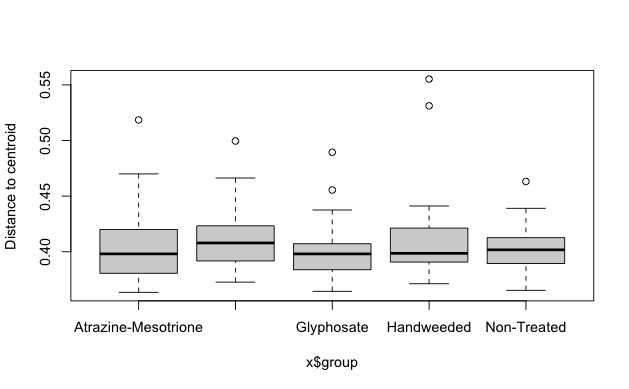

```r
ps_betadispr(ps_rare_sub, groupingvar = "Herbicide")
```

```
Analysis of Variance Table

Response: Distances
           Df   Sum Sq    Mean Sq F value Pr(>F)
Groups      2 0.001682 0.00084096  0.9478 0.3897
Residuals 161 0.142847 0.00088725

Permutation test for homogeneity of multivariate dispersions
Permutation: free
Number of permutations: 1000

Response: Distances
           Df   Sum Sq    Mean Sq      F N.Perm Pr(>F)
Groups      2 0.001682 0.00084096 0.9478   1000 0.3656
Residuals 161 0.142847 0.00088725

Pairwise comparisons:
(Observed p-value below diagonal, permuted p-value above diagonal)
            Chemical    Hand Non-Treated
Chemical             0.98202      0.1339
Hand         0.97790              0.3057
Non-Treated  0.13961 0.31930
$stats
          [,1]      [,2]      [,3]
[1,] 0.3678724 0.3712730 0.3653358
[2,] 0.3914997 0.3907178 0.3894408
[3,] 0.4069683 0.3985758 0.4017338
[4,] 0.4198506 0.4212779 0.4126745
[5,] 0.4591917 0.4411483 0.4390542

$n
[1] 99 32 33

$conf
          [,1]      [,2]      [,3]
[1,] 0.4024663 0.3900402 0.3953436
[2,] 0.4114703 0.4071115 0.4081241

$out
   G046SG    G070SG    G087SG    G123SG    G131SG    G065SG    G125SG    G151SG
0.4911052 0.5250529 0.4726503 0.4968193 0.4692099 0.5311635 0.5552741 0.4631531

$group
[1] 1 1 1 1 1 2 2 3

$names
[1] "Chemical"    "Hand"        "Non-Treated"
```

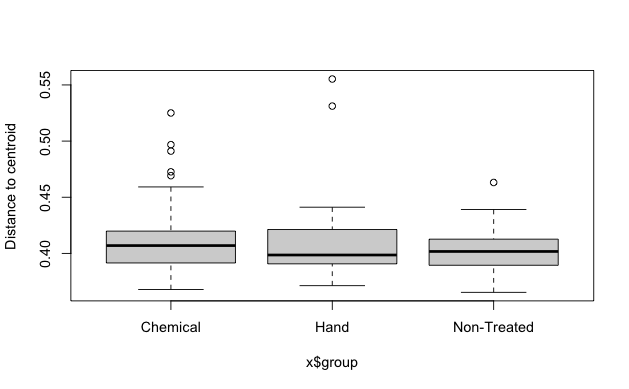

```r
ps_betadispr(ps_rare_sub, groupingvar = "Mode")
```

```
Analysis of Variance Table

Response: Distances
           Df   Sum Sq    Mean Sq F value Pr(>F)
Groups      2 0.001119 0.00055970  0.6361 0.5307
Residuals 161 0.141654 0.00087984

Permutation test for homogeneity of multivariate dispersions
Permutation: free
Number of permutations: 1000

Response: Distances
           Df   Sum Sq    Mean Sq      F N.Perm Pr(>F)
Groups      2 0.001119 0.00055970 0.6361   1000 0.5455
Residuals 161 0.141654 0.00087984

Pairwise comparisons:
(Observed p-value below diagonal, permuted p-value above diagonal)
        T1      T2     T3
T1         0.28172 0.3257
T2 0.29177         0.9810
T3 0.31167 0.98337
$stats
          [,1]      [,2]      [,3]
[1,] 0.3751393 0.3651628 0.3656380
[2,] 0.3983422 0.3889047 0.3843976
[3,] 0.4102601 0.3985027 0.4009712
[4,] 0.4266630 0.4186156 0.4162396
[5,] 0.4483672 0.4529592 0.4619116

$n
[1] 56 54 54

$conf
          [,1]      [,2]      [,3]
[1,] 0.4042806 0.3921145 0.3941248
[2,] 0.4162397 0.4048909 0.4078175

$out
   G046SG    G065SG    G070SG    G087SG    G123SG    G125SG
0.4859161 0.5363026 0.5212376 0.4661354 0.4943452 0.5607126

$group
[1] 1 2 2 2 3 3

$names
[1] "T1" "T2" "T3"
```

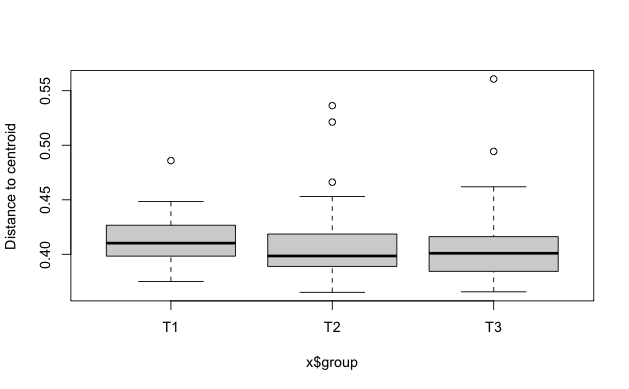

```r
ps_betadispr(ps_rare_sub, groupingvar = "Time")
```

```r
beta_boxplot<-function (physeq, method = "bray", group)
{
  require("phyloseq")
  require("ggplot2")
  group2samp <- list()
  group_list <- get_variable(sample_data(physeq), group)
  for (groups in levels(group_list)) {
    target_group <- which(group_list == groups)
    group2samp[[groups]] <- sample_names(physeq)[target_group]
  }
  beta_div_dist <- phyloseq::distance(physeq = physeq, method = method)
  beta_div_dist <- as(beta_div_dist, "matrix")
  dist_df <- data.frame()
  counter <- 1
  for (groups in names(group2samp)) {
    sub_dist <- beta_div_dist[group2samp[[groups]], group2samp[[groups]]]
    no_samp_col <- ncol(sub_dist)
    no_samp_row <- nrow(sub_dist)
    for (cols in seq(no_samp_col)) {
      if (cols > 1) {
        for (rows in seq((cols - 1))) {
          dist_df[counter, "sample_pair"] <- paste0(colnames(sub_dist)[cols],
            "-", rownames(sub_dist)[rows])
          dist_df[counter, "group"] <- groups
          dist_df[counter, "beta_div_method"] <- method
          dist_df[counter, "beta_div_value"] <- sub_dist[rows,
            cols]
          counter = counter + 1
        }
      }
    }
  }
  plot_boxplot <- ggplot(data = dist_df, aes(x = group, y = beta_div_value,
    color = group)) + geom_boxplot(outlier.shape = NA) +
    geom_jitter() + theme_bw() + xlab(group) + ylab(method) +
    theme(axis.text.x = element_text(angle = 45, vjust = 1,
      hjust = 1))
  list_Out <- list(data = dist_df, plot = plot_boxplot)
  return(list_Out)
}
```

```r
ggsave("/Users/gordoncuster/Desktop/Git_Projects/Herbicide_Microbes_PT1/Figures/FinalPlots/CombinedFigures/Supp_figure_16S_combined_rare_within_group_beta.eps", plot_combined_treatment_beta_disper)
```

Examination of dissimliarity across time points by treatment and then again by all chemical treatments combined.

```r
ggsave("/Users/gordoncuster/Desktop/Git_Projects/Herbicide_Microbes_PT1/Figures/FinalPlots/betadisper_chemicaltreatment.eps", beta_disper_Chemical_treatment_16S, dpi = 600)
```

```r
beta_lm(beta_div_chemical_combined_T1_T2_T3, Herbicide = "Chemical")
```

```
Call:
lm(formula = beta_div_value ~ Time, data = df_sub)

Residuals:
      Min        1Q    Median        3Q       Max
-0.113000 -0.022554 -0.003221  0.018446  0.142723

Coefficients:
              Estimate Std. Error t value Pr(>|t|)
(Intercept)  0.6023336  0.0013349  451.22   <2e-16 ***
Time        -0.0012390  0.0001041  -11.91   <2e-16 ***
---
Signif. codes:  0 ‘***’ 0.001 ‘**’ 0.01 ‘*’ 0.05 ‘.’ 0.1 ‘ ’ 1

Residual standard error: 0.03433 on 1583 degrees of freedom
Multiple R-squared:  0.08218,   Adjusted R-squared:  0.0816
F-statistic: 141.7 on 1 and 1583 DF,  p-value: < 2.2e-16

 (Intercept)         Time
 0.602333553 -0.001238983
```

treatment to control

```r
plotDistances = function(p, m, s, d) {

  # calc distances
  wu = phyloseq::distance(p, m)
  wu.m = melt(as.matrix(wu))

  # remove self-comparisons
  wu.m = wu.m %>%
    filter(as.character(Var1) != as.character(Var2)) %>%
    mutate_if(is.factor,as.character)

  # get sample data (S4 error OK and expected)
  sd = data.frame(sample_data(p)) %>%
    select(s, d) %>%
    mutate_if(is.factor,as.character)
  sd$Herbicide <- factor(sd$Herbicide, levels = c("Non-Treated", "Hand", "Aatrex", "Clarity", "Roundup Powermax"))

  # combined distances with sample data
  colnames(sd) = c("Var1", "Type1")
  wu.sd = left_join(wu.m, sd, by = "Var1")

  colnames(sd) = c("Var2", "Type2")
  wu.sd = left_join(wu.sd, sd, by = "Var2")

  #remove this line to plot all comparisons.
  #wu.sd = wu.sd %>% filter(Type1 == "Hand" | Type1 == "Non-Treated")

  # plot
  ggplot(wu.sd, aes(x = Type2, y = value)) +
    theme_bw() +
    geom_point() +
    geom_boxplot(aes(color = ifelse(Type1 == Type2, "red", "black"))) +
    scale_color_identity() +
    facet_wrap(~ Type1, scales = "free_x") +
    theme(axis.text.x=element_text(angle = 45, hjust = 1, size = 5)) +
    ggtitle(paste0("Distance Metric = ", m))

}
```

```r
a<-plotDistances(p = subset_samples(physeq= ps_rare, Time=="T1"), m = "bray", s = "Barcode_ID_G", d = "Herbicide")
a <- a + ggtitle("Time 1 Bray-Curtis Dissimlarities")
#ggsave("/Users/gordoncuster/Desktop/Git_Projects/Herbicide_Microbes_PT1/Figures/16S_T1_rare_allgroup_beta.pdf")
ggsave("/Users/gordoncuster/Desktop/Git_Projects/Herbicide_Microbes_PT1/Figures/16S_T1_rare_allgroup_beta_multicomparison.pdf")
b<-plotDistances(p = subset_samples(physeq= ps_rare, Time=="T2"), m = "bray", s = "Barcode_ID_G", d = "Herbicide")
b <-b + ggtitle("Time 2 Bray-Curtis Dissimlarities")
#ggsave("/Users/gordoncuster/Desktop/Git_Projects/Herbicide_Microbes_PT1/Figures/16S_T2_rare_allgroup_beta.pdf")
ggsave("/Users/gordoncuster/Desktop/Git_Projects/Herbicide_Microbes_PT1/Figures/16S_T2_rare_allgroup_beta_multicomparison.pdf")
c<-plotDistances(p = subset_samples(physeq= ps_rare, Time=="T3"), m = "bray", s = "Barcode_ID_G", d = "Herbicide")
c<- c + ggtitle("Time 3 Bray-Curtis Dissimlarities")
#ggsave("/Users/gordoncuster/Desktop/Git_Projects/Herbicide_Microbes_PT1/Figures/16S_T3_rare_allgroup_beta.pdf")
ggsave("/Users/gordoncuster/Desktop/Git_Projects/Herbicide_Microbes_PT1/Figures/16S_T3_rare_allgroup_beta_multicomparison.pdf")

library(ggpubr)
ggarrange(a, b, c, ncol = 1)
ggsave("/Users/gordoncuster/Desktop/Git_Projects/Herbicide_Microbes_PT1/Figures/16S_combined_rare_allgroup_beta_multi_comparison.pdf", width = 7, height = 10)
```

Taxon abundance bar plot

```r
#create super long color vector
col_vector <- c("#000000", "#FFFF00", "#1CE6FF", "#FF34FF", "#FF4A46", "#008941", "#006FA6", "#A30059",
        "#FFDBE5", "#7A4900", "#0000A6", "#63FFAC", "#B79762", "#004D43", "#8FB0FF", "#997D87",
        "#5A0007", "#809693", "#FEFFE6", "#1B4400", "#4FC601", "#3B5DFF", "#4A3B53", "#FF2F80",
        "#61615A", "#BA0900", "#6B7900", "#00C2A0", "#FFAA92", "#FF90C9", "#B903AA", "#D16100",
        "#DDEFFF", "#000035", "#7B4F4B", "#A1C299", "#300018", "#0AA6D8", "#013349", "#00846F",
        "#372101", "#FFB500", "#C2FFED", "#A079BF", "#CC0744", "#C0B9B2", "#C2FF99", "#001E09",
        "#00489C", "#6F0062", "#0CBD66", "#EEC3FF", "#456D75", "#B77B68", "#7A87A1", "#788D66",
        "#885578", "#FAD09F", "#FF8A9A", "#D157A0", "#BEC459", "#456648", "#0086ED", "#886F4C",

        "#34362D", "#B4A8BD", "#00A6AA", "#452C2C", "#636375", "#A3C8C9", "#FF913F", "#938A81",
        "#575329", "#00FECF", "#B05B6F", "#8CD0FF", "#3B9700", "#04F757", "#C8A1A1", "#1E6E00",
        "#7900D7", "#A77500", "#6367A9", "#A05837", "#6B002C", "#772600", "#D790FF", "#9B9700",
        "#549E79", "#FFF69F", "#201625", "#72418F", "#BC23FF", "#99ADC0", "#3A2465", "#922329",
        "#5B4534", "#FDE8DC", "#404E55", "#0089A3", "#CB7E98", "#A4E804", "#324E72", "#6A3A4C",
        "#83AB58", "#001C1E", "#D1F7CE", "#004B28", "#C8D0F6", "#A3A489", "#806C66", "#222800",
        "#BF5650", "#E83000", "#66796D", "#DA007C", "#FF1A59", "#8ADBB4", "#1E0200", "#5B4E51",
        "#C895C5", "#320033", "#FF6832", "#66E1D3", "#CFCDAC", "#D0AC94", "#7ED379", "#012C58",

        "#7A7BFF", "#D68E01", "#353339", "#78AFA1", "#FEB2C6", "#75797C", "#837393", "#943A4D",
        "#B5F4FF", "#D2DCD5", "#9556BD", "#6A714A", "#001325", "#02525F", "#0AA3F7", "#E98176",
        "#DBD5DD", "#5EBCD1", "#3D4F44", "#7E6405", "#02684E", "#962B75", "#8D8546", "#9695C5",
        "#E773CE", "#D86A78", "#3E89BE", "#CA834E", "#518A87", "#5B113C", "#55813B", "#E704C4",
        "#00005F", "#A97399", "#4B8160", "#59738A", "#FF5DA7", "#F7C9BF", "#643127", "#513A01",
        "#6B94AA", "#51A058", "#A45B02", "#1D1702", "#E20027", "#E7AB63", "#4C6001", "#9C6966",
        "#64547B", "#97979E", "#006A66", "#391406", "#F4D749", "#0045D2", "#006C31", "#DDB6D0",
        "#7C6571", "#9FB2A4", "#00D891", "#15A08A", "#BC65E9", "#FFFFFE", "#C6DC99", "#203B3C",

        "#671190", "#6B3A64", "#F5E1FF", "#FFA0F2", "#CCAA35", "#374527", "#8BB400", "#797868",
        "#C6005A", "#3B000A", "#C86240", "#29607C", "#402334", "#7D5A44", "#CCB87C", "#B88183",
        "#AA5199", "#B5D6C3", "#A38469", "#9F94F0", "#A74571", "#B894A6", "#71BB8C", "#00B433",
        "#789EC9", "#6D80BA", "#953F00", "#5EFF03", "#E4FFFC", "#1BE177", "#BCB1E5", "#76912F",
        "#003109", "#0060CD", "#D20096", "#895563", "#29201D", "#5B3213", "#A76F42", "#89412E",
        "#1A3A2A", "#494B5A", "#A88C85", "#F4ABAA", "#A3F3AB", "#00C6C8", "#EA8B66", "#958A9F",
        "#BDC9D2", "#9FA064", "#BE4700", "#658188", "#83A485", "#453C23", "#47675D", "#3A3F00",
        "#061203", "#DFFB71", "#868E7E", "#98D058", "#6C8F7D", "#D7BFC2", "#3C3E6E", "#D83D66",

        "#2F5D9B", "#6C5E46", "#D25B88", "#5B656C", "#00B57F", "#545C46", "#866097", "#365D25",
        "#252F99", "#00CCFF", "#674E60", "#FC009C", "#92896B")
```

```r
phylumGlommed <- tax_glom(ps_rare, "Phylum")

#t1
phylumGlommed_herb_t1 <- merge_samples(subset_samples(physeq= phylumGlommed, Time=="T1"), group = "Herbicide")
phylumGlommed_herb_t1 <- transform_sample_counts(phylumGlommed_herb_t1, function(OTU) OTU/sum(OTU))
sample_data(phylumGlommed_herb_t1)$Herbicide <- factor(sample_data(phylumGlommed_herb_t1)$Herbicide, levels = c(1, 2, 3, 4, 5),
       labels = c("Non-Treated", "Hand", "Aatrex", "Clarity", "Roundup Powermax"))

plot_bar(phylumGlommed_herb_t1, x = "Herbicide", fill = "Phylum")  + theme_classic() + ggtitle("Proportional Taxon Abundances Time 1") +
theme(legend.position="bottom") + guides(fill=guide_legend(nrow=6)) + geom_bar(stat="identity") + theme(axis.text.x=element_text(angle = 45, hjust = 1, size = 5)) +
scale_fill_manual(values = col_vector)
ggsave("/Users/gordoncuster/Desktop/Git_Projects/Herbicide_Microbes_PT1/Figures/16S_Taxon_barplot_t1.pdf")

#t2
phylumGlommed_herb_t2 <- merge_samples(subset_samples(physeq= phylumGlommed, Time=="T2"), group = "Herbicide")
phylumGlommed_herb_t2 <- transform_sample_counts(phylumGlommed_herb_t2, function(OTU) OTU/sum(OTU))
sample_data(phylumGlommed_herb_t2)$Herbicide <- factor(sample_data(phylumGlommed_herb_t2)$Herbicide, levels = c(1, 2, 3, 4, 5),
       labels = c("Non-Treated", "Hand", "Aatrex", "Clarity", "Roundup Powermax"))

plot_bar(phylumGlommed_herb_t2, x = "Herbicide", fill = "Phylum")  + theme_classic() + ggtitle("Proportional Taxon Abundances Time 1") +
theme(legend.position="bottom") + guides(fill=guide_legend(nrow=6)) + geom_bar(stat="identity") + theme(axis.text.x=element_text(angle = 45, hjust = 1, size = 5)) +
scale_fill_manual(values = col_vector)
ggsave("/Users/gordoncuster/Desktop/Git_Projects/Herbicide_Microbes_Pt1/Figures/16S_Taxon_barplot_t2.pdf")

#t3
phylumGlommed_herb_t3 <- merge_samples(subset_samples(physeq= phylumGlommed, Time=="T3"), group = "Herbicide")
phylumGlommed_herb_t3 <- transform_sample_counts(phylumGlommed_herb_t3, function(OTU) OTU/sum(OTU))
sample_data(phylumGlommed_herb_t3)$Herbicide <- factor(sample_data(phylumGlommed_herb_t3)$Herbicide, levels = c(1, 2, 3, 4, 5),
       labels = c("Non-Treated", "Hand", "Aatrex", "Clarity", "Roundup Powermax"))

plot_bar(phylumGlommed_herb_t3, x = "Herbicide", fill = "Phylum")  + theme_classic() + ggtitle("Proportional Taxon Abundances Time 1") +
theme(legend.position="bottom") + guides(fill=guide_legend(nrow=6)) + geom_bar(stat="identity") + theme(axis.text.x=element_text(angle = 45, hjust = 1, size = 5)) +
scale_fill_manual(values = col_vector)
ggsave("/Users/gordoncuster/Desktop/Git_Projects/Herbicide_Microbes_Pt1/Figures/16S_Taxon_barplot_t3.pdf")
```

Combined herbicide and time bar plot for exploration

```r
sample_data(ps_rare)$herb_time<-paste(sample_data(ps_rare)$Herbicide, sample_data(ps_rare)$Time, sep = "_")
ps_rare_for_barplot <- prune_taxa(taxa_sums(ps_rare) > 50, ps_rare)
plot_bar(ps_rare_for_barplot, x= "herb_time", fill = "Family") + scale_fill_manual(values = col_vector) + geom_bar(stat="identity")
ggsave("/Users/gordoncuster/Desktop/Git_Projects/Herbicide_Microbes_PT1/Figures/16S_BarPlot_Herbicide_Time.pdf", width = 20, height = 11)
```

Linear modeling of abundant taxa.

```r
Tax_glom_Subset <- function (physeq, y = "taxLevel", nreturns = "Number of returns"){
   ps_1<- tax_glom(ps_rare_sub, taxrank = y )
    myTaxa <- names(sort(taxa_sums(ps_1), decreasing = TRUE)[1:nreturns])
       ps_1_sub <- prune_taxa(myTaxa, ps_1)
  return(ps_1_sub)
}


ps_rare_family_top25<-Tax_glom_Subset(physeq = ps_rare, nreturns = 25, y = "Family")

myTaxa <- names(sort(taxa_sums(ps_rare), decreasing = TRUE)[1:25])
ps_rare_asv_top25 <- prune_taxa(myTaxa, ps_rare)


#explore top 25 taxa with plot bar
plot_bar(ps_rare_family_top25, x= "herb_time", fill = "Family") + scale_fill_manual(values = col_vector) + geom_bar(stat="identity")
plot_bar(ps_rare_family_top25, x= "Time", fill = "Family") + scale_fill_manual(values = col_vector) + geom_bar(stat="identity")
plot_bar(ps_rare_family_top25, x= "Herbicide", fill = "Family") + scale_fill_manual(values = col_vector) + geom_bar(stat="identity")


#write function to wrangle data prior to anova

abund_aov_wrangle <- function (physeq, y = "Tax_Level"){
  tax<-tax_table(physeq)[,y]
   meta<-data.frame(sample_data(physeq))
  counts<-data.frame(otu_table(physeq))
  rownames(counts) <- tax[,1]
  counts<-data.frame(t(counts))
   counts$Time <- meta$Time
   counts$Herbicide <- meta$Herbicide
  counts$Herb_time <- meta$herb_time
  return(counts)
}

test<-abund_aov_wrangle(ps_rare_family_top25, y = "Family")



mod_abund<-function(count_tab, IV = "Groups to be tested") {
   for(j in 1:length(unique(count_tab[,"Herbicide"]))){
         data <- count_tab %>% filter(Herbicide == unique(count_tab$Herbicide)[j])
           #change this to the number of returns from the tax_glom_subset function
   for (i in 1:25) {
            mod <- aov(unlist(data[i]) ~ matrix(data[,IV]))
            #sanity check
            #print(c(j, i))
   if(summary(mod)[[1]][["Pr(>F)"]][1] <= 0.05) {
            #print(summary(mod))
     print(c(as.character(unique(count_tab[,"Herbicide"]))[j], names(data)[i]))
              boxplot(unlist(data[i]) ~ unlist(data[IV]), main =paste(names(data[i]), as.character(unique(count_tab[,"Herbicide"]))[j]), xlab= "Time", ylab="Abundance")
           }
         }
      }
    }


mod_abund(test, IV = "Time")
```